# analise superstore

Eduardo Lisboa

2025-04-23

##Análise dos dados do dataset SuperStore

O dataset a ser analisado contém informações sobre vendas da empresa SuperStore

Atribuindo o dataset à um dataframe

```r
  library(tidyverse)
```

```r
  library(ggplot2)
  sales <- read.csv("train.csv")
```

Visualizado um pouco dos dados e as caracteristicas das tabelas

```r
  head(sales)
```

```
##   Row.ID       Order.ID Order.Date  Ship.Date      Ship.Mode Customer.ID
## 1      1 CA-2017-152156 08/11/2017 11/11/2017   Second Class    CG-12520
## 2      2 CA-2017-152156 08/11/2017 11/11/2017   Second Class    CG-12520
## 3      3 CA-2017-138688 12/06/2017 16/06/2017   Second Class    DV-13045
## 4      4 US-2016-108966 11/10/2016 18/10/2016 Standard Class    SO-20335
## 5      5 US-2016-108966 11/10/2016 18/10/2016 Standard Class    SO-20335
## 6      6 CA-2015-115812 09/06/2015 14/06/2015 Standard Class    BH-11710
##     Customer.Name   Segment       Country            City      State
## 1     Claire Gute  Consumer United States       Henderson   Kentucky
## 2     Claire Gute  Consumer United States       Henderson   Kentucky
## 3 Darrin Van Huff Corporate United States     Los Angeles California
## 4  Sean O'Donnell  Consumer United States Fort Lauderdale    Florida
## 5  Sean O'Donnell  Consumer United States Fort Lauderdale    Florida
## 6 Brosina Hoffman  Consumer United States     Los Angeles California
##   Postal.Code Region      Product.ID        Category Sub.Category
## 1       42420  South FUR-BO-10001798       Furniture    Bookcases
## 2       42420  South FUR-CH-10000454       Furniture       Chairs
## 3       90036   West OFF-LA-10000240 Office Supplies       Labels
## 4       33311  South FUR-TA-10000577       Furniture       Tables
## 5       33311  South OFF-ST-10000760 Office Supplies      Storage
## 6       90032   West FUR-FU-10001487       Furniture  Furnishings
##                                                       Product.Name    Sales
## 1                                Bush Somerset Collection Bookcase 261.9600
## 2      Hon Deluxe Fabric Upholstered Stacking Chairs, Rounded Back 731.9400
## 3        Self-Adhesive Address Labels for Typewriters by Universal  14.6200
## 4                    Bretford CR4500 Series Slim Rectangular Table 957.5775
## 5                                   Eldon Fold 'N Roll Cart System  22.3680
## 6 Eldon Expressions Wood and Plastic Desk Accessories, Cherry Wood  48.8600
```

```r
  str(sales)
```

```
## 'data.frame':    9800 obs. of  18 variables:
##  $ Row.ID       : int  1 2 3 4 5 6 7 8 9 10 ...
##  $ Order.ID     : chr  "CA-2017-152156" "CA-2017-152156" "CA-2017-138688" "US-2016-108966" ...
##  $ Order.Date   : chr  "08/11/2017" "08/11/2017" "12/06/2017" "11/10/2016" ...
##  $ Ship.Date    : chr  "11/11/2017" "11/11/2017" "16/06/2017" "18/10/2016" ...
##  $ Ship.Mode    : chr  "Second Class" "Second Class" "Second Class" "Standard Class" ...
##  $ Customer.ID  : chr  "CG-12520" "CG-12520" "DV-13045" "SO-20335" ...
##  $ Customer.Name: chr  "Claire Gute" "Claire Gute" "Darrin Van Huff" "Sean O'Donnell" ...
##  $ Segment      : chr  "Consumer" "Consumer" "Corporate" "Consumer" ...
##  $ Country      : chr  "United States" "United States" "United States" "United States" ...
##  $ City         : chr  "Henderson" "Henderson" "Los Angeles" "Fort Lauderdale" ...
##  $ State        : chr  "Kentucky" "Kentucky" "California" "Florida" ...
##  $ Postal.Code  : int  42420 42420 90036 33311 33311 90032 90032 90032 90032 90032 ...
##  $ Region       : chr  "South" "South" "West" "South" ...
##  $ Product.ID   : chr  "FUR-BO-10001798" "FUR-CH-10000454" "OFF-LA-10000240" "FUR-TA-10000577" ...
##  $ Category     : chr  "Furniture" "Furniture" "Office Supplies" "Furniture" ...
##  $ Sub.Category : chr  "Bookcases" "Chairs" "Labels" "Tables" ...
##  $ Product.Name : chr  "Bush Somerset Collection Bookcase" "Hon Deluxe Fabric Upholstered Stacking Chairs, Rounded Back" "Self-Adhesive Address Labels for Typewriters by Universal" "Bretford CR4500 Series Slim Rectangular Table" ...
##  $ Sales        : num  262 731.9 14.6 957.6 22.4 ...
```

Identificando dados com valores NA ou Nulos

```r
  colSums(is.na(sales))
```

```
##        Row.ID      Order.ID    Order.Date     Ship.Date     Ship.Mode
##             0             0             0             0             0
##   Customer.ID Customer.Name       Segment       Country          City
##             0             0             0             0             0
##         State   Postal.Code        Region    Product.ID      Category
##             0            11             0             0             0
##  Sub.Category  Product.Name         Sales
##             0             0             0
```

Passando os dados que estão sem o código postal para um dataframe caso necessidade de realizar mais consultas e verificando se há duplicatas

```r
  sales_exc <- sales[is.na(sales$Postal.Code), ]
  sales_clean <- sales[!is.na(sales$Postal.Code), ]
  sum(duplicated(sales_clean))
```

```
## [1] 0
```

Verificando se há erros de classificação de dados com poucos tipos

```r
  table(sales_clean$Ship.Mode)
```

```
##
##    First Class       Same Day   Second Class Standard Class
##           1501            538           1901           5849
```

```r
  table(sales_clean$Segment)
```

```
##
##    Consumer   Corporate Home Office
##        5096        2948        1745
```

```r
  table(sales_clean$Category)
```

```
##
##       Furniture Office Supplies      Technology
##            2076            5903            1810
```

```r
  table(sales_clean$Region)
```

```
##
## Central    East   South    West
##    2277    2774    1598    3140
```

Convertendo o formato das datas para melhor maneabilidade das informações e criando uma nova coluna com o ano e mês separado

```r
  sales_clean_v2 <- sales_clean
  sales_clean_v2$Order.Date <- as.Date(sales_clean_v2$Order.Date, format = "%d/%m/%Y")
  sales_clean_v2$Ship.Date <- as.Date(sales_clean_v2$Ship.Date, format = "%d/%m/%Y")
  sales_clean_v2 <- sales_clean_v2 %>%
    mutate(order_year = year(Order.Date)) %>%
    mutate(order_month = month(Order.Date))
```

Limpeza e organização dos dados já feita

Inicio da Análise Exploratória

Vamos verificar as vendas por ano

```r
  sales_by_year <- sales_clean_v2 %>%
    group_by(order_year) %>%
    summarise(total_sales = sum(Sales, na.rm = "TRUE"))
  head(sales_by_year)
```

```
## # A tibble: 4 × 2
##   order_year total_sales
##        <dbl>       <dbl>
## 1       2015     479856.
## 2       2016     454316.
## 3       2017     597225.
## 4       2018     721210.
```

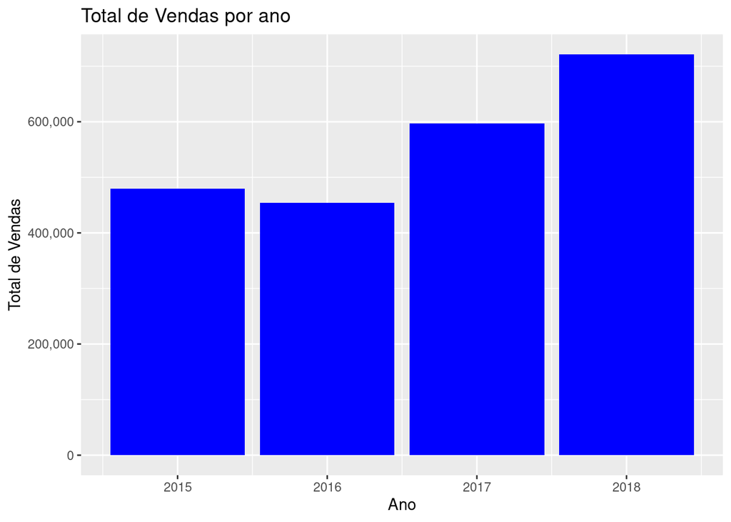

```r
  ggplot(sales_by_year, aes(x = order_year, y = total_sales)) +
    geom_bar(stat = "identity", fill = "blue") +
    scale_y_continuous(labels = scales::comma) +
    labs(title = "Total de Vendas por ano", x = "Ano", y = "Total de Vendas")
```

Podemos observar que estamos com 2 anos seguidos de crescimento, que ultrapassaram o total de vendas de 2015 e 2016

Vamos agora verificar o histórioco mensal de nossos 4 anos

iniciando em 2015 até 2018

```r
  sales_month_geral <- sales_clean_v2 %>%
  mutate(month_name = factor(month(order_month, label = TRUE, abbr = FALSE))) %>%
  group_by(month_name) %>%
  summarise(total_sales_month = sum(Sales, na.rm = TRUE))
  head(sales_month_geral)
```

```
## # A tibble: 6 × 2
##   month_name total_sales_month
##   <ord>                  <dbl>
## 1 January               91982.
## 2 February              59371.
## 3 March                197574.
## 4 April                134988.
## 5 May                  154087.
## 6 June                 145838.
```

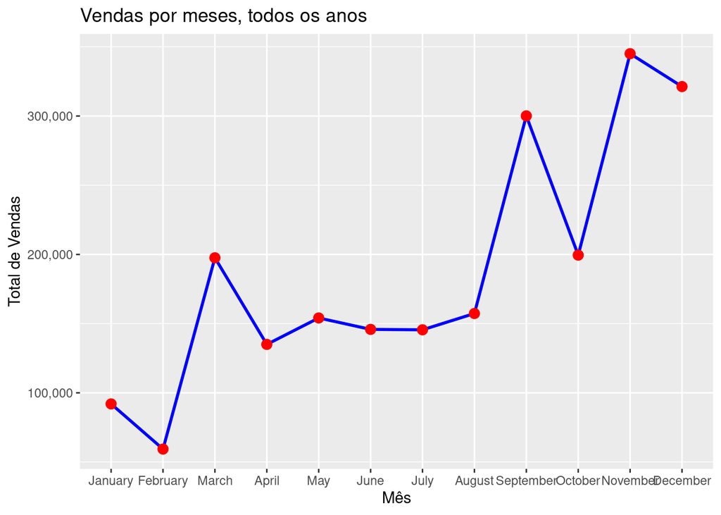

```r
  ggplot(sales_month_geral, aes(x = month_name, y = total_sales_month, group = 1))+
    geom_line(color = "blue", linewidth = 1) +
    geom_point(color = "red", size = 3) +
    scale_y_continuous(labels = scales::comma) +
    labs(title = "Vendas por meses, todos os anos", x = "Mês", y = "Total de Vendas")
```

Observamos que as menores vendas foram nos meses de janeiro e fevereiro, com a estabilidade das vendas até agosto, tendo um grande crescimento a partir de setembro seguido de uma queda em outubro e o pico das vendas em novembro, sendo os melhores meses, novembro e dezembro

Agora vamos verificar por regiao, as vendas totais que registramos

```r
  sales_by_region <- sales_clean_v2 %>%
  group_by(Region) %>%
  summarise(total_sales = n()) %>%
  arrange(desc(total_sales))
  head(sales_by_region)
```

```
## # A tibble: 4 × 2
##   Region  total_sales
##   <chr>         <int>
## 1 West           3140
## 2 East           2774
## 3 Central        2277
## 4 South          1598
```

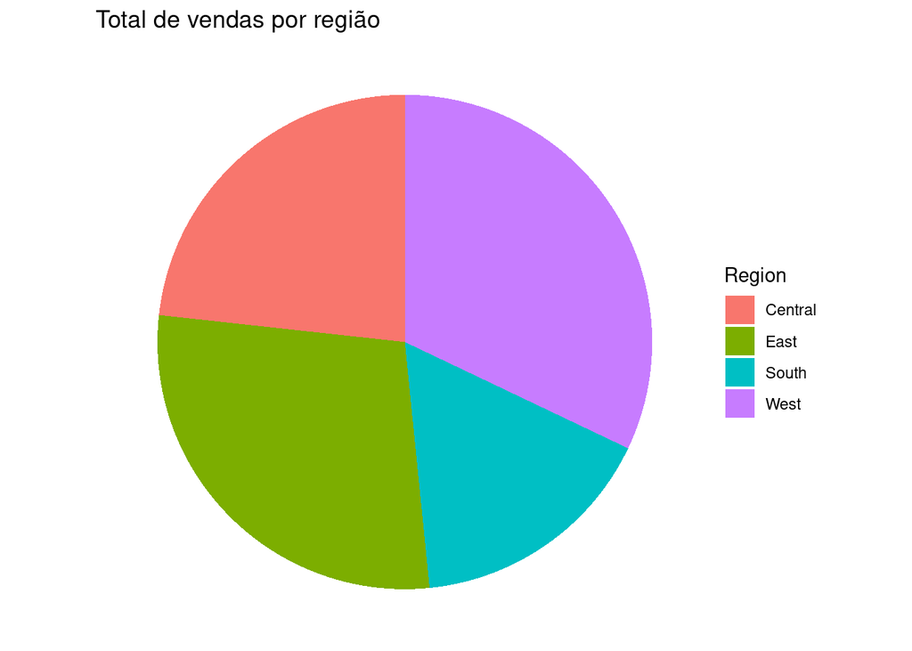

```r
  ggplot(sales_by_region, aes(x = "", y = total_sales, fill = Region)) +
  geom_bar(stat = "identity", width = 1) +
  coord_polar("y", start = 0) +
  theme_void() +
  labs(title = "Total de vendas por região", x = "Região", y = "Total de vendas")
```

Arrecadação total

```r
  value_by_region <- sales_clean_v2 %>%
  group_by(Region) %>%
  summarise(total_sales = sum(Sales, na.rm = FALSE)) %>%
  arrange(desc(total_sales))
  head(value_by_region)
```

```
## # A tibble: 4 × 2
##   Region  total_sales
##   <chr>         <dbl>
## 1 West        710220.
## 2 East        660589.
## 3 Central     492647.
## 4 South       389151.
```

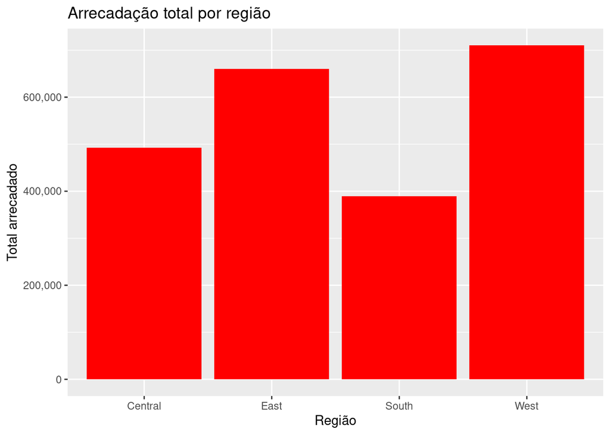

```r
  ggplot(value_by_region, aes(x = Region, y = total_sales)) +
  geom_bar(stat="identity", fill = "red") +
  scale_y_continuous(labels = scales::comma) +
  labs(title = "Arrecadação total por região", x = "Região", y = "Total arrecadado")
```

Verificamos que a região West tem maior quantidade de vendas e consequentemente maior valor arrecadado

###Resumo da Analise O que pode ser percebido:

1° - Foi realizada a analise dos ultimos quatro anos dos dados de venda, sendo informado que o ano de 2018 teve a maior arrecadação, assim como descrito no gráfico

2° - Foi percebido que entre as regiões que foram registradas as vendas, a região West foi a que mais vendeu e mais arrecadou entre as outras regiões

4° - Com os dados coletados não temos informações sufucientes para calcular o lucro/prejuizo por produto

5° - Não temos informções de descontos para podermos comparar com as vendas e extrair se há aumento ou diminuição dos lucros com descontos

Recomendações

1 - Por ter sido verificado a sazonalidade das vendas, há a possibilidade de a equipe de marketing avaliar novas abordagens para aumentar o numero de vendas nos meses que já há maior demanda, passando por uma possível remanejamento do orçamento de marketing dos meses com pouca demanda para meses com maior potencial.

3 - Com os dados, apesar de não ter sido o foco desta análise, será possível a avaliação das categorias e itens mais vendidos em cada região, podendo desta forma dar inicio à um remanejamento logistico, de modo à diminuir custos de logistica, tendo como benefício também a diminuição dos prazos de entrega para o cliente